# Ford GoBike

## Preliminary Wrangling

> Dataset lists the data of 183412 trips made by ford GoBike Bike Sharing app.

```python
# import all packages and set plots to be embedded inline
import numpy as np
import pandas as pd
import matplotlib.pyplot as plt
import seaborn as sb

%matplotlib inline
```

> Learn about factors affecting trip duration

```python
df = pd.read_csv('201902-fordgobike-tripdata.csv')
```

```python
df.head()
```

|  | duration_sec | start_time | end_time | start_station_id | start_station_name | start_station_latitude | start_station_longitude | end_station_id | end_station_name | end_station_latitude | end_station_longitude | bike_id | user_type | member_birth_year | member_gender | bike_share_for_all_trip |
| --- | --- | --- | --- | --- | --- | --- | --- | --- | --- | --- | --- | --- | --- | --- | --- | --- |
| 0 | 52185 | 2019-02-28 17:32:10.1450 | 2019-03-01 08:01:55.9750 | 21.0 | Montgomery St BART Station (Market St at 2nd St) | 37.789625 | -122.400811 | 13.0 | Commercial St at Montgomery St | 37.794231 | -122.402923 | 4902 | Customer | 1984.0 | Male | No |
| 1 | 42521 | 2019-02-28 18:53:21.7890 | 2019-03-01 06:42:03.0560 | 23.0 | The Embarcadero at Steuart St | 37.791464 | -122.391034 | 81.0 | Berry St at 4th St | 37.775880 | -122.393170 | 2535 | Customer | NaN | NaN | No |
| 2 | 61854 | 2019-02-28 12:13:13.2180 | 2019-03-01 05:24:08.1460 | 86.0 | Market St at Dolores St | 37.769305 | -122.426826 | 3.0 | Powell St BART Station (Market St at 4th St) | 37.786375 | -122.404904 | 5905 | Customer | 1972.0 | Male | No |
| 3 | 36490 | 2019-02-28 17:54:26.0100 | 2019-03-01 04:02:36.8420 | 375.0 | Grove St at Masonic Ave | 37.774836 | -122.446546 | 70.0 | Central Ave at Fell St | 37.773311 | -122.444293 | 6638 | Subscriber | 1989.0 | Other | No |
| 4 | 1585 | 2019-02-28 23:54:18.5490 | 2019-03-01 00:20:44.0740 | 7.0 | Frank H Ogawa Plaza | 37.804562 | -122.271738 | 222.0 | 10th Ave at E 15th St | 37.792714 | -122.248780 | 4898 | Subscriber | 1974.0 | Male | Yes |

```python
print(set(df['user_type']))
```

```
{'Subscriber', 'Customer'}
```

```python
df.dtypes
```

```
duration_sec                 int64
start_time                  object
end_time                    object
start_station_id           float64
start_station_name          object
start_station_latitude     float64
start_station_longitude    float64
end_station_id             float64
end_station_name            object
end_station_latitude       float64
end_station_longitude      float64
bike_id                      int64
user_type                   object
member_birth_year          float64
member_gender               object
bike_share_for_all_trip     object
dtype: object
```

```python
df.dropna()
```

|  | duration_sec | start_time | end_time | start_station_id | start_station_name | start_station_latitude | start_station_longitude | end_station_id | end_station_name | end_station_latitude | end_station_longitude | bike_id | user_type | member_birth_year | member_gender | bike_share_for_all_trip |
| --- | --- | --- | --- | --- | --- | --- | --- | --- | --- | --- | --- | --- | --- | --- | --- | --- |
| 0 | 52185 | 2019-02-28 17:32:10.1450 | 2019-03-01 08:01:55.9750 | 21.0 | Montgomery St BART Station (Market St at 2nd St) | 37.789625 | -122.400811 | 13.0 | Commercial St at Montgomery St | 37.794231 | -122.402923 | 4902 | Customer | 1984.0 | Male | No |
| 2 | 61854 | 2019-02-28 12:13:13.2180 | 2019-03-01 05:24:08.1460 | 86.0 | Market St at Dolores St | 37.769305 | -122.426826 | 3.0 | Powell St BART Station (Market St at 4th St) | 37.786375 | -122.404904 | 5905 | Customer | 1972.0 | Male | No |
| 3 | 36490 | 2019-02-28 17:54:26.0100 | 2019-03-01 04:02:36.8420 | 375.0 | Grove St at Masonic Ave | 37.774836 | -122.446546 | 70.0 | Central Ave at Fell St | 37.773311 | -122.444293 | 6638 | Subscriber | 1989.0 | Other | No |
| 4 | 1585 | 2019-02-28 23:54:18.5490 | 2019-03-01 00:20:44.0740 | 7.0 | Frank H Ogawa Plaza | 37.804562 | -122.271738 | 222.0 | 10th Ave at E 15th St | 37.792714 | -122.248780 | 4898 | Subscriber | 1974.0 | Male | Yes |
| 5 | 1793 | 2019-02-28 23:49:58.6320 | 2019-03-01 00:19:51.7600 | 93.0 | 4th St at Mission Bay Blvd S | 37.770407 | -122.391198 | 323.0 | Broadway at Kearny | 37.798014 | -122.405950 | 5200 | Subscriber | 1959.0 | Male | No |
| ... | ... | ... | ... | ... | ... | ... | ... | ... | ... | ... | ... | ... | ... | ... | ... | ... |
| 183407 | 480 | 2019-02-01 00:04:49.7240 | 2019-02-01 00:12:50.0340 | 27.0 | Beale St at Harrison St | 37.788059 | -122.391865 | 324.0 | Union Square (Powell St at Post St) | 37.788300 | -122.408531 | 4832 | Subscriber | 1996.0 | Male | No |
| 183408 | 313 | 2019-02-01 00:05:34.7440 | 2019-02-01 00:10:48.5020 | 21.0 | Montgomery St BART Station (Market St at 2nd St) | 37.789625 | -122.400811 | 66.0 | 3rd St at Townsend St | 37.778742 | -122.392741 | 4960 | Subscriber | 1984.0 | Male | No |
| 183409 | 141 | 2019-02-01 00:06:05.5490 | 2019-02-01 00:08:27.2200 | 278.0 | The Alameda at Bush St | 37.331932 | -121.904888 | 277.0 | Morrison Ave at Julian St | 37.333658 | -121.908586 | 3824 | Subscriber | 1990.0 | Male | Yes |
| 183410 | 139 | 2019-02-01 00:05:34.3600 | 2019-02-01 00:07:54.2870 | 220.0 | San Pablo Ave at MLK Jr Way | 37.811351 | -122.273422 | 216.0 | San Pablo Ave at 27th St | 37.817827 | -122.275698 | 5095 | Subscriber | 1988.0 | Male | No |
| 183411 | 271 | 2019-02-01 00:00:20.6360 | 2019-02-01 00:04:52.0580 | 24.0 | Spear St at Folsom St | 37.789677 | -122.390428 | 37.0 | 2nd St at Folsom St | 37.785000 | -122.395936 | 1057 | Subscriber | 1989.0 | Male | No |

174952 rows × 16 columns

```python
df['member_birth_year'].astype('Int64')
```

```
0         1984
1          NaN
2         1972
3         1989
4         1974
          ...
183407    1996
183408    1984
183409    1990
183410    1988
183411    1989
Name: member_birth_year, Length: 183412, dtype: Int64
```

```python
df['start_time'] = pd.to_datetime(df['start_time'])
df['hour'] =df['start_time'].dt.strftime('%-H').astype('int')
df['weekday'] = df['start_time'].dt.strftime('%w').astype('int') #index of day in week; Sunday:0 , Monday: 1, ...
df['start_station_id'] = df['start_station_id'].astype('Int64')
df['end_station_id'] = df['end_station_id'].astype('Int64')
```

```python
df['age'] = pd.DatetimeIndex(df['start_time']).year - df['member_birth_year'].astype('Int64')
```

```python
df['bike_share_for_all_trip'] = df['bike_share_for_all_trip'] == "Yes"

df['subscribed'] = df['user_type'] == "Subscriber"
```

```python
df['duration_min'] = df['duration_sec'] // 60
```

```python
del df['end_time']


del df['start_station_name']
del df['end_station_name']

del df['member_birth_year']
del df['user_type']

del df['duration_sec']
```

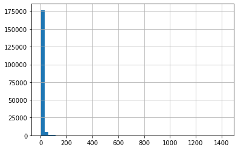

```python
df['duration_min'].hist(bins=50)
```

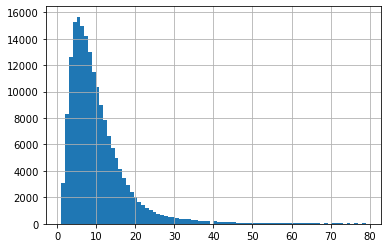

```python
df = df[df['duration_min'] < 80]
df['duration_min'].hist(bins=80)
```

```python
df.to_csv('data_wrangled.csv')
```

```python
df.head()
```

|  | start_time | start_station_id | start_station_latitude | start_station_longitude | end_station_id | end_station_latitude | end_station_longitude | bike_id | member_gender | bike_share_for_all_trip | hour | weekday | age | subscribed | duration_min |
| --- | --- | --- | --- | --- | --- | --- | --- | --- | --- | --- | --- | --- | --- | --- | --- |
| 4 | 2019-02-28 23:54:18.549 | 7 | 37.804562 | -122.271738 | 222 | 37.792714 | -122.248780 | 4898 | Male | True | 23 | 4 | 45 | True | 26 |
| 5 | 2019-02-28 23:49:58.632 | 93 | 37.770407 | -122.391198 | 323 | 37.798014 | -122.405950 | 5200 | Male | False | 23 | 4 | 60 | True | 29 |
| 6 | 2019-02-28 23:55:35.104 | 300 | 37.317298 | -121.884995 | 312 | 37.329732 | -121.901782 | 3803 | Female | False | 23 | 4 | 36 | True | 19 |
| 7 | 2019-02-28 23:41:06.766 | 10 | 37.795393 | -122.404770 | 127 | 37.756708 | -122.421025 | 6329 | Male | False | 23 | 4 | 30 | True | 26 |
| 8 | 2019-02-28 23:41:48.790 | 10 | 37.795393 | -122.404770 | 127 | 37.756708 | -122.421025 | 6548 | Other | False | 23 | 4 | 31 | True | 26 |

```python
df.describe()
```

|  | start_station_id | start_station_latitude | start_station_longitude | end_station_id | end_station_latitude | end_station_longitude | bike_id | hour | weekday | age | duration_min |
| --- | --- | --- | --- | --- | --- | --- | --- | --- | --- | --- | --- |
| count | 182041.000000 | 182236.000000 | 182236.000000 | 182041.000000 | 182236.000000 | 182236.000000 | 182236.000000 | 182236.000000 | 182236.000000 | 174214.000000 | 182236.000000 |
| mean | 138.594575 | 37.771193 | -122.352514 | 136.147236 | 37.771394 | -122.352091 | 4475.054654 | 13.459448 | 3.040684 | 34.188423 | 10.074497 |
| std | 111.636256 | 0.099693 | 0.117183 | 111.316525 | 0.099595 | 0.116748 | 1662.907962 | 4.728240 | 1.757453 | 10.115068 | 8.132060 |
| min | 3.000000 | 37.317298 | -122.453704 | 3.000000 | 37.317298 | -122.453704 | 11.000000 | 0.000000 | 0.000000 | 18.000000 | 1.000000 |
| 25% | 47.000000 | 37.770083 | -122.411901 | 44.000000 | 37.770407 | -122.411726 | 3786.000000 | 9.000000 | 2.000000 | 27.000000 | 5.000000 |
| 50% | 104.000000 | 37.780760 | -122.398285 | 100.000000 | 37.780955 | -122.397437 | 4958.000000 | 14.000000 | 3.000000 | 32.000000 | 8.000000 |
| 75% | 239.000000 | 37.797280 | -122.285633 | 233.000000 | 37.797320 | -122.288045 | 5502.000000 | 17.000000 | 4.000000 | 39.000000 | 13.000000 |
| max | 398.000000 | 37.880222 | -121.874119 | 398.000000 | 37.880222 | -121.874119 | 6645.000000 | 23.000000 | 6.000000 | 141.000000 | 79.000000 |

### What is the structure of your dataset?

> There are 183412 trips in the dataset with 16 features ( duration_sec, start_time, end_time, start_station_id, start_station_name, start_station_latitude, start_station_longitude, end_station_id, end_station_name, end_station_latitude, end_station_longitude, bike_id, user_type, member_birth_year, member_gender, bike_share_for_all_trip) All data is from February 2019, and depeding on station coordinates minimum and maximum; (37.317298, -122.453704) and (37.880222, -121.874119) all in San Francisco area.

station IDs should be integers; And seeing that user types are only subscriber and customer, boolean field wether rider is a customer is easier to use duration in minutes rather than seconds is more appropriate user age rather than birthyear, since start times convers short timespan, users of same age are same generation. I also added start_day to represent day in Week, as it ouwld propably have effect on usage;

### What features in the dataset do you think will help support your investigation into your feature(s) of interest?

> duration of trips, start adn end stations, users age and gender, and whther is a subscriber, and whether bike shared all trip.

## Univariate Exploration

```python
def hist(col, bins, xlabel=None, title=None, ylabel=None):
    if not xlabel:
        xlabel = col.capitalize()
    if not ylabel:
        ylabel = 'Count'
    if not title:
        title = 'Distribution of ' + xlabel

    df[col].hist(bins=bins)
    plt.title(title)
    plt.xlabel(xlabel)
    plt.ylabel(ylabel)
```

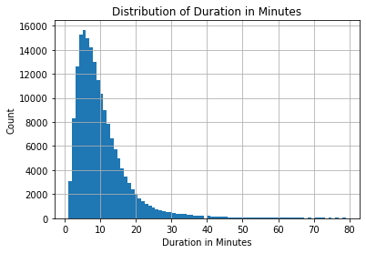

```python
hist('duration_min', 80, "Duration in Minutes")
```

> Trips usually take less than 20 minutes, and most trips 4:7 minutes

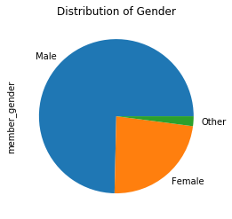

```python
df['member_gender'].value_counts().plot.pie()
plt.title('Distribution of Gender')
```

> Most users are males, aound 3 to 1 to females

[figure not shown]

```python
df['subscribed'].value_counts().plot.pie(labels=['Non-subscribers', 'Subscribers'])
plt.title('Subscribed and Non-subscribed User Percentage')
# plt.xticks([False, True], ['Non-subscribers', 'Subscribers']);
```

> most of user are subscriber to the service

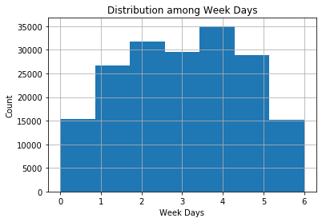

```python
hist('weekday', 7, "Week Days")
plt.title('Distribution among Week Days')
```

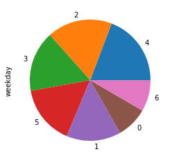

```python
df['weekday'].value_counts().plot.pie()
```

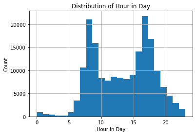

```python
hist('hour', 24, "Hour in Day")
```

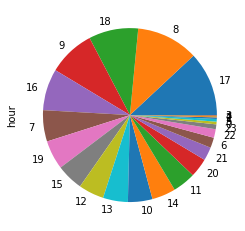

```python
df['hour'].value_counts().plot.pie()
```

> Most Riders ride on 7:9 am and then again, 4 to 7 pm

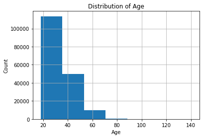

```python
hist('age', 7)
```

> most users are in age band 20:40

### Discuss the distribution(s) of your variable(s) of interest. Were there any unusual points? Did you need to perform any transformations?

> I expected more users of age 13:20 to ride bikes, but I guess those may enjoy to own thier personal bikes.

> start datetime made more since transform to weekdays and day hours, because those would show more significance. Also changing time durtion to minutes made data more presentable, since accuracy to seconds to not really needed here.

### Of the features you investigated, were there any unusual distributions? Did you perform any operations on the data to tidy, adjust, or change the form of the data? If so, why did you do this?

> I expected more users of age 13:20 to ride bikes, but I guess those may enjoy to own thier personal bikes.

> start datetime made more since transform to weekdays and day hours, because those would show more significance. Also changing time durtion to minutes made data more presentable, since accuracy to seconds to not really needed here.

## Bivariate Exploration

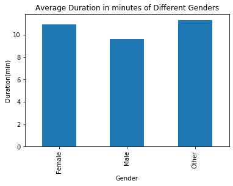

```python
df.groupby('member_gender')['duration_min'].mean().plot(kind='bar')
plt.title('Average Duration in minutes of Different Genders')
plt.xlabel('Gender')
plt.ylabel('Duration(min)')
```

> Males riders ride the shorter trips on average

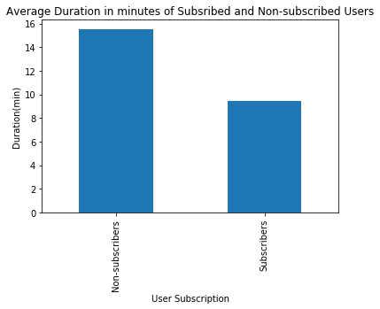

```python
df.groupby('subscribed')['duration_min'].mean().plot(kind='bar');
plt.xticks([False, True], ['Non-subscribers', 'Subscribers']);
plt.title('Average Duration in minutes of Subsribed and Non-subscribed Users')
plt.xlabel('User Subscription')
plt.ylabel('Duration(min)')
```

> Non subscriber rider ride for longer durations, 1.5 times the sibscriber trips average duration.

[output not shown]

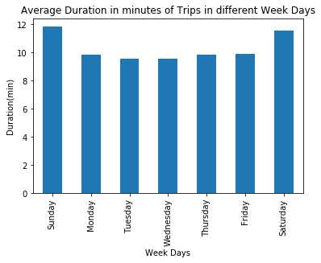

```python
df.groupby('weekday')['duration_min'].mean().plot(kind='bar');
plt.title('Average Duration in minutes of Trips in different Week Days')
plt.xlabel('Week Days')
plt.ylabel('Duration(min)')
plt.xticks(range(7), ['Sunday', 'Monday', 'Tuesday', 'Wednesday', 'Thursday', 'Friday', 'Saturday'])
```

### Talk about some of the relationships you observed in this part of the investigation. How did the feature(s) of interest vary with other features in the dataset?

> looking at the relation between trip duration and different factors, the following could be noticed;

> > Males riders ride the shorter trips on average

> > Non subscriber rider ride for longer durations, 1.5 times the sibscriber trips average duration.

> > On weekends, riders take longer trips for pleasure as expected, since on work days riders may prefer other means of transportation for longer trips.

### Did you observe any interesting relationships between the other features (not the main feature(s) of interest)?

> nonsubscribers take longer trips on average!

## Multivariate Exploration

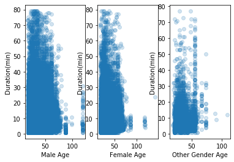

```python
plt.title('Trip duration for different genders and age bands')

plt.subplot(1, 3, 1)
df_male = df[df['member_gender'] == 'Male']
plot_male = plt.scatter(df_male['age'], df_male['duration_min'], alpha=.2)
plt.xlabel('Male Age')
plt.ylabel('Duration(min)')

plt.subplot(1, 3, 2)
df_female = df[df['member_gender'] == 'Female']
plot_female = plt.scatter(df_female['age'], df_female['duration_min'], alpha=.2)
plt.xlabel('Female Age')
plt.ylabel('Duration(min)')

plt.subplot(1, 3, 3)
df_other = df[df['member_gender'] == 'Other']
plot_other = plt.scatter(df_other['age'], df_other['duration_min'], alpha=.2)
plt.xlabel('Other Gender Age')
plt.ylabel('Duration(min)')
```

> Gender distribution according to age and trip duration is similar, however longer trip duration were mianly done by male riders.

### Talk about some of the relationships you observed in this part of the investigation. Were there features that strengthened each other in terms of looking at your feature(s) of interest?

> riders different genders recorded the longest ride periods between age of 20 and 40.

### Were there any interesting or surprising interactions between features?

> Although Male rider have higher ride dutations, in range of 60:80 minutes, they had the lowset average among genders.

```python
!python3 -m nbconvert exploration.ipynb
```

```
[NbConvertApp] Converting notebook exploration.ipynb to html
[NbConvertApp] Writing 573041 bytes to exploration.html
```